# EM&Guassian Mixture Model

## GMM 聚类

```r
library(mclust)
```

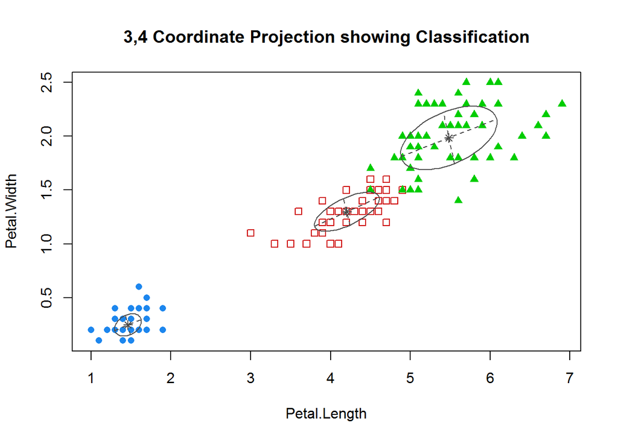

```r
mc <-  Mclust(iris[,1:4], 3)
plot(mc, iris[,1:4], what="classification",dimens=c(3,4))
```

```r
table(iris$Species, mc$classification)
```

```
##
##               1  2  3
##   setosa     50  0  0
##   versicolor  0 45  5
##   virginica   0  0 50
```